# Excersises Ch.3

Ignacia Rivera

June 25, 2018

## 3.1 Binomial probability distirbution

For situations when there are only two possible outcomes over $N$ trials and $Z$ meassures the number of times a specified outcome occurs and $p$ is the probability that the specified outcome occurs.

$$Pr\{Z = k\} = p(k,N) = \Bigg[\frac{N-k+1}{k}\Bigg] \Bigg [\frac{p}{1-p}\Bigg] p(k-1,N)$$

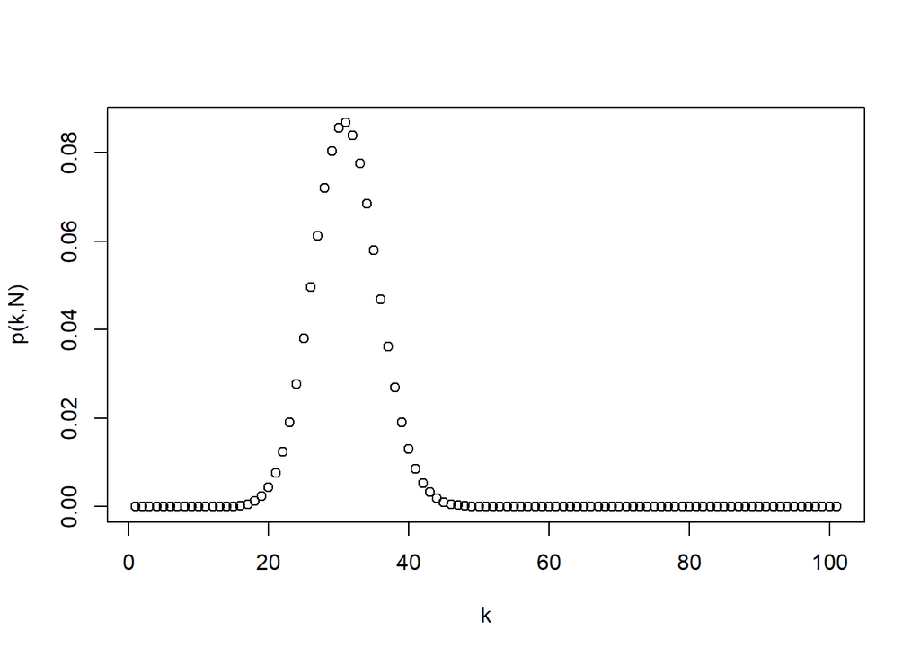

```r
binom <- function (p,N) {

# calculates probability of zero successes
p0 = (1 - p)^N
# geneerates a vector to store the prob of k successes
pk = rep(NA, N+1)
pk[1]= p0


for (k in 1:N){

  # calculates prob of k successes
  pkN = ((N-k+1)/k)*(p/(1-p))*pk[k]
  # stores prob of k successes
  pk[k+1] = pkN

   }

# plots k vs prob of k successes
plot(seq(0:N), pk, xlab="k", ylab="p(k,N)")

}

binom(0.3, 100)
```

### An ecological scenario: sampling for pests

The chance that a fruit is infested is $p$. We sample $N$ fruits and test whether they are infested or not. The probability that $k$ of them are infested is given by the binomial distribution. What is the distirbution of infested fruits if we sample 10 fruits and $p = 0.1, 0.2 or 0.3$?

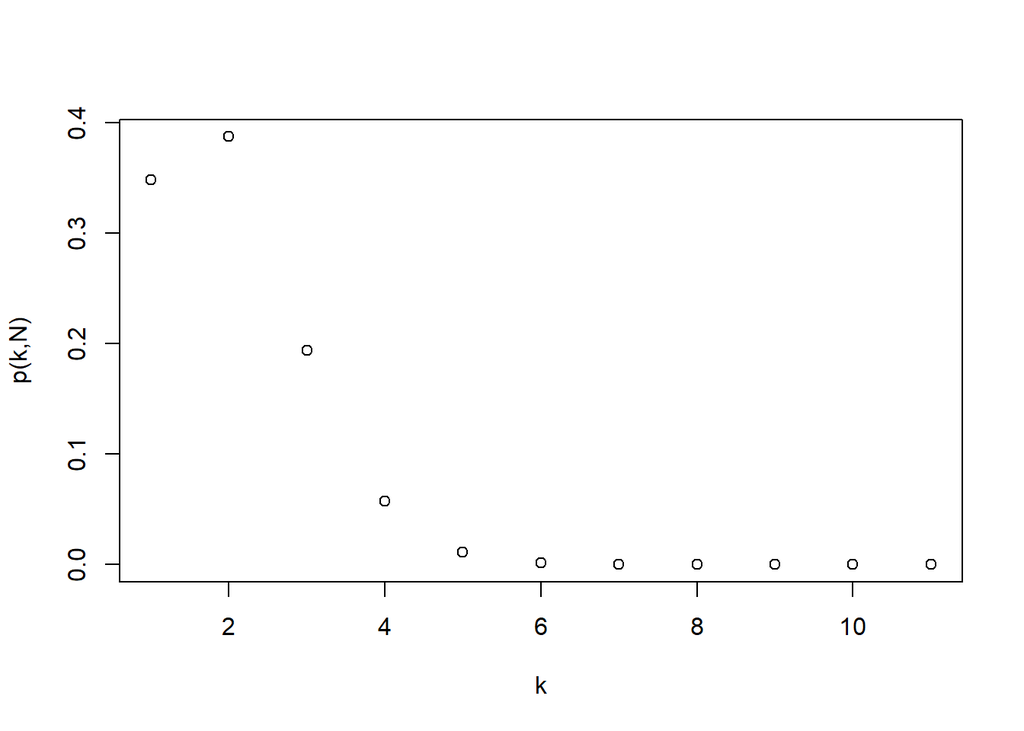

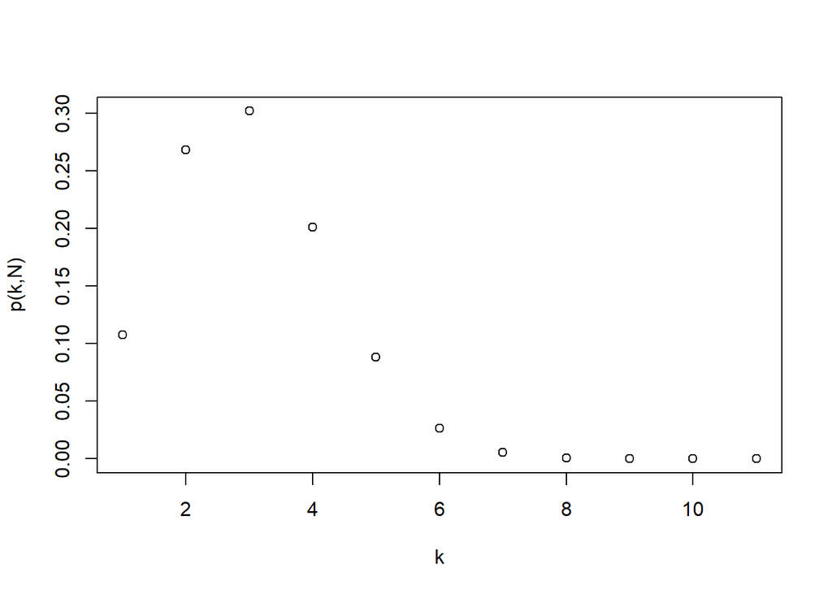

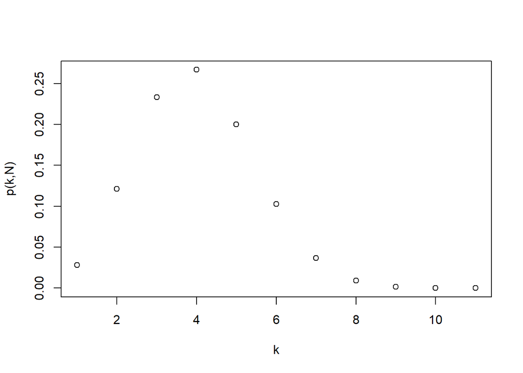

## 3.2 The poisson distribution

The random variable takes discrete values during continuous sampling.

$$Pr\{Z(t) = k\} = p(k,t)= \Bigg(\frac{rt}{k}\Bigg) p(k-1,t)$$

```
## i = 1 k=  1 pkt =  0.07326256 sum =  0.09157819i = 2 k=  2 pkt =  0.1465251 sum =  0.2381033i = 3 k=  3 pkt =  0.1953668 sum =  0.4334701i = 4 k=  4 pkt =  0.1953668 sum =  0.6288369i = 5 k=  5 pkt =  0.1562935 sum =  0.7851304i = 6 k=  6 pkt =  0.1041956 sum =  0.889326i = 7 k=  7 pkt =  0.05954…
```

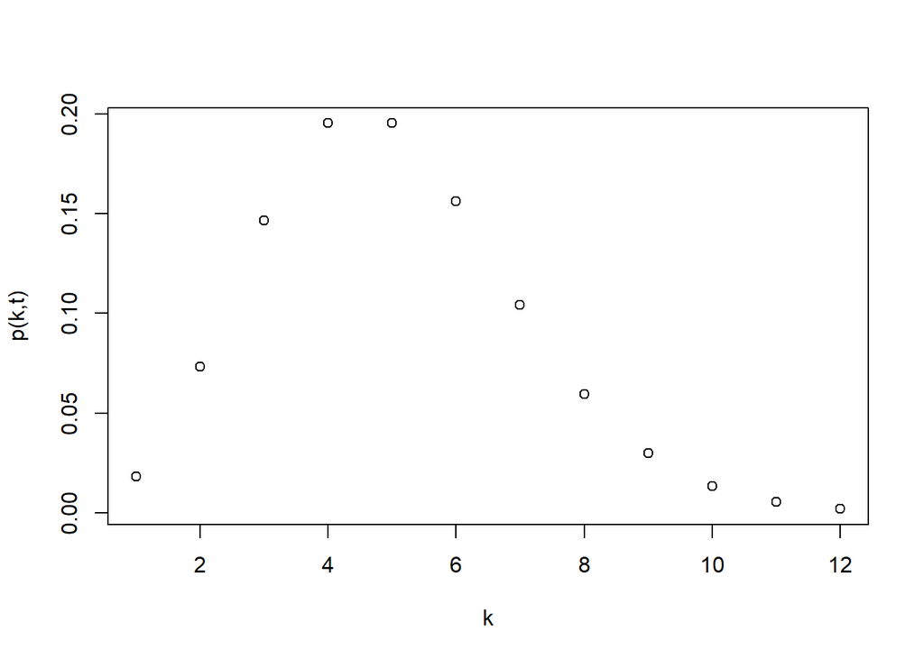

```r
poisson.dist <- function (r,t,cutoff) {

# calculate prob of zero successes
p0 = exp(-r*t)
# sets variable sum to stop the iteration
sum= p0
# starts the vector to sabe probabilities, iniciates with prob of zero
pk= NA
pk[1] = p0

i = 1

while (sum < cutoff){

  k = i
  pkt = ((r*t)/k)*pk[i]
  pk[i+1] = pkt
  sum =  sum + pkt
  #prints iteration values
  cat( 'i =', i, 'k= ', k, 'pkt = ', pkt, 'sum = ', sum)

  i= i+1

}

plot(seq(0:(length(pk)-1)), pk, xlab="k", ylab="p(k,t)")

}

poisson.dist(r= 0.1, t=40, cutoff=0.999)
```

## 3.3 The Montecarlo method

One way to increase our confidence in the methods we use is to test models and methods on sets of data in which we know exactly what is happening (i.e. we know the generation mechanism behind). The Montecarlo method is a useful method to generate such data by using random-number generators.

### Generating an individual random variables from a binomial distirbution

```r
ran.binom <- function (N,p) {

# chooses a random number from a uniform distirbution
U = runif(1)
# sets variable sum to stop the iteration
sum= 0
# set initial k
k = 0
# stores probabilities to get p(k-1)
p0 = (1 - p)^N
pk = p0

i = 1

while (sum < U){

  k= k+1
  # calculates prob of k successes
  pkN = ((N-k+1)/k)*(p/(1-p))*pk[i]
  pk[i+1] = pkN

  sum =  sum + pkN

  #prints iteration values
  cat( 'i =', i, 'k= ', k, 'pkN = ', pkN, 'sum = ', sum)

  i= i+1

}

}

ran.binom(40, 0.2)
```

```
## i = 1 k=  1 pkN =  0.001329228 sum =  0.001329228i = 2 k=  2 pkN =  0.006479986 sum =  0.007809214i = 3 k=  3 pkN =  0.02051996 sum =  0.02832917i = 4 k=  4 pkN =  0.0474524 sum =  0.07578157i = 5 k=  5 pkN =  0.08541432 sum =  0.1611959i = 6 k=  6 pkN =  0.1245626 sum =  0.2857584i = 7 k=  7 pkN…
```

### An Ecological Scenario : The simple population model with process and observation uncertainty

This excersise illustrates how we can generate data based on a basic population model introducing process and observation uncertainty.

Population dynamics are given by:

$$N_{t+1} = s N_t + b + W_t$$

Abundance observations are given by:

$$N_{obs,t} = N_t + V_t$$

Where $s$ is the survival probability, $b$ is the number of new individuals (i.e. births), $W_t$ is a random distribution that introduces process uncertainty by affecting the birth rate in each time period, and $V_t$ is another random variable that introduces observation uncertainty by affecting the observed abundance.

```r
pop.dynamics.obsv <- function( t, s, b, sigma.N, sigma.W, sigma.V, N.0){

  # sets first period abundance equal to N0
  N.t = N.0 + rnorm(n= 1, mean= 0, sd= sigma.N)
  N.obs = N.0 + rnorm(1, 0, sigma.V)


for (i in 1:t){

  N.t[i+1] = s*N.t[i]+ b + rnorm(1, 0, sigma.W)
  N.obs[i+1] =  N.t[i+1] + rnorm(1, 0, sigma.V)

}

  lag.plot(N.obs, lags=1, labels = FALSE, do.lines= FALSE)

}
```

#### How process uncertainty affects the relationship between $N_t$ and $N_{t-1}$?

To introduce process uncertainty we introduce a random variable drawn from a normal distribution with mean = 0 and sd= $\sigma_w$. In this case $\sigma_w = 10$

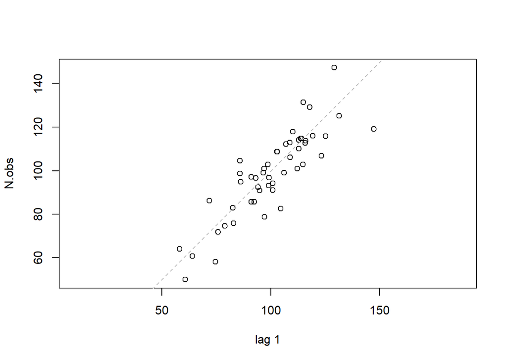

#### Adding observational uncertainty

To introduce observational uncertainty we introduce a random variable drawn from a normal distribution with mean = 0 and sd= $\sigma_v$. In this case $\sigma_v = 10$. Now the relationship between the observed abundance in time $t$ with the observed abundance in time $t-1$ is less clear.

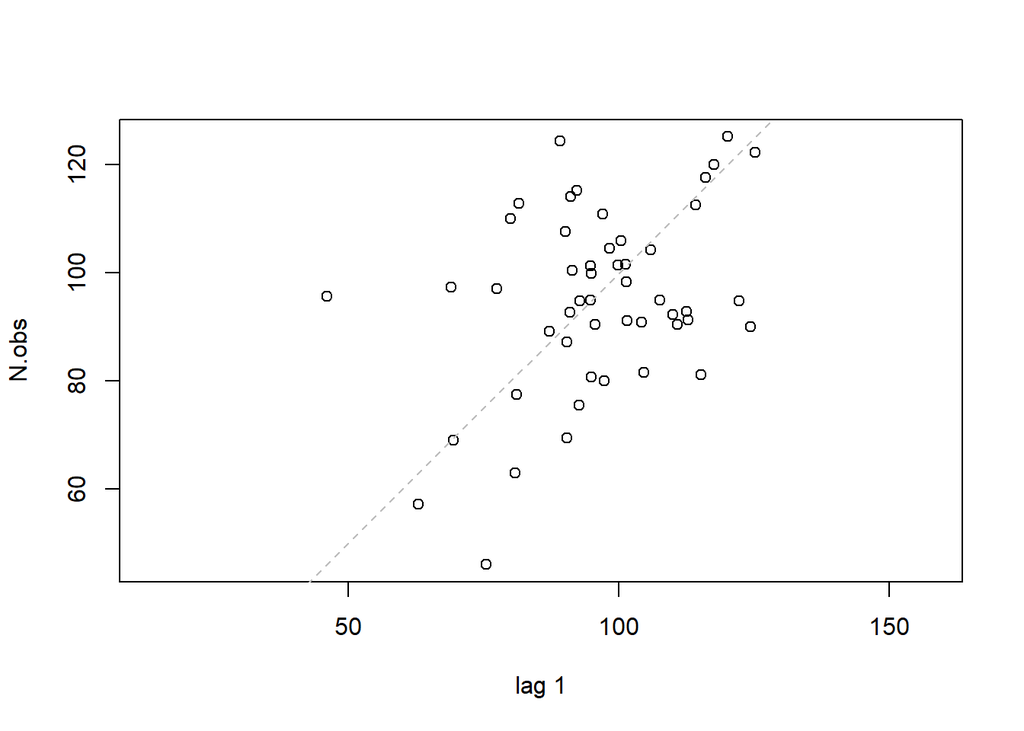